# A quick tour of mfpp

Zsolt T. Kosztyan, Aamir Saghir

15 June 2022

# Introduction

The package of *Matrix-based Flexible Project planning* (**mfpp**) models project structures for four types of project management approaches (PMas). The Table 1 summarizes the features of the project management structures.

|  | **Features** |  |  |
| --- | --- | --- | --- |
| **Approaches** | **Project structure** | **New tasks** | **Multiple modes** |
| Traditional (TPMa) | Fixed | Not allowed | Handled |
| Agile (APMa) | Flexible | Not allowed | Not handled |
| Extreme (XPMa) | Flexible | Allowed | Not handled |
| Hybrid (HPMa) | Flexible | Allowed | Handled |

**Table 1:** Comparison of various traditional and flexible project management approaches (PMas) (see Kosztyan, Szalkai, 2020)

Packages and programs only support traditional project management approaches, where both dependencies between tasks, and as well as task occurrences are fixed. Nevertheless, all packages, including the proposed **mfpp** package have to offer to plan and schedule these types of projects. This package is R version of MATLAB functions published by Kosztyan (2022).

# Load necessary libraries

```r
library(mfpp) # Matrix-based Flexible Project Planning
library(knitr) # Apply graphical elements
```

# Build fixed matrix-based projects and calculate their demands to support TPMa

The logic domain (LD) specifies the structure of the project. LD is an $N$ by $N$ (sub)matrix, where $N$ is the number of tasks. Diagonal values represent task priorities of task completion, where 1 indicates mandatory, and a lower value indicates supplementary tasks. Out-diagonal values represent dependencies between tasks, where value 1 indicates fixed, but lower values indicate flexible dependencies between tasks. In the case of acyclic graphs, the LD can be reordered to the upper triangular matrix, which is assumed in this package.

Time domain (TD) represents the time demands (i.e. duration) of tasks. TD is an $N$ by $w$ matrix, where the $w$ is the number of completion modes. This example specifies a binary logic plan, with one completion mode.

## Specify logic domain (LD), and time domain (TD)

TPMa allows only binary values in LD.

```r
# Calculatation of EST, EFT, LST and LFT times of activity of a project

# Define a 3 by 3 upper triangular binary matrix (DSM) of logic domain (LD) of a project.

# Specify the precendence of three tasks
# Diagonal values indicates the priority of tasks
# 1=the task is mandatory
LD<-rbind(c(1,0,1), c(0,1,0), c(0,0,1))

# Define a 3 by 1 vector of time durations of a project, where the durations are 3,4,5 respectively.
TD<-c(3,4,5)

# Calculate project duration (total project time, TPT)
TPT<-tpt(LD,TD)

summary(TPT)
```

```
#>
#>
#>  Table of schedule
#>     Dur EST EFT LST LFT TF SST SFT SF Is.Crit
#> a_1   3   0   3   0   3  0   0   3  0    TRUE
#> a_2   4   0   4   4   8  4   0   4  4   FALSE
#> a_3   5   3   8   3   8  0   3   8  0    TRUE
```

```r
# Specify initial scheduled start time, where the delay is 1 for the .
SST <- c(1,1,0)

# Including scheduled starts and finishes.

TPT<-tpt(LD,TD,SST)

# Print schedule table
summary(TPT)
```

```
#>
#>
#>  Table of schedule
#>     Dur EST EFT LST LFT TF SST SFT SF Is.Crit
#> a_1   3   0   3   0   3  0   1   4 -1    TRUE
#> a_2   4   0   4   4   8  4   1   5  3   FALSE
#> a_3   5   3   8   3   8  0   4   9 -1    TRUE
```

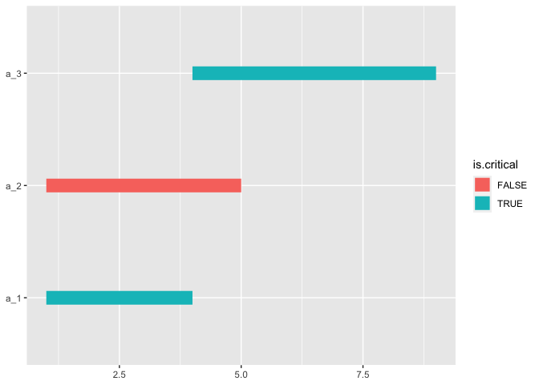

```r
# Plot the scheduled Gantt chart
plot(TPT,sched="S")
```

The function *tpt* project duration (total project time, TPT), calculates schedules of tasks, such as early start time (EST), early finish time (EFT), late start time (LST), late finish time (LFT), scheduled start time (SST), scheduled finish time (SFT). The plot function draws a Gantt chart, for the early, late, or scheduled start times.

## Specify cost domain (CD), quality domain (QD), and resource domain (RD)

Both CD, and QD are $N$ by $w$ matrices. CD is mandatory, while QD is optional. RD is an optional $N$ by $w \cdot r$ matrix, where $r$ is the number of resources.

```r
# Specify seed
set.seed(6)
# Specify the cost demands
CD<-c(10,20,24)

cat("\nTotal Project Cost (TPC): ",tpc(LD,CD))
```

```
#>
#> Total Project Cost (TPC):  54
```

```r
# Specify quality parameters
q<-runif(3)

# For fixed project plan the TPQ is the geometric mean of quality parameters

cat("\nTotal Project Quality (TPC): ",tpq(LD,LD,q))
```

```
#>
#> Total Project Quality (TPC):  0.5316529
```

```r
# Calculate relative quality for the selected completion modes

QD2<-cbind(q,runif(3)) # Generate two completion modes

# Calculate relative quality considering the best choice

cat("\nRelative TPQ: ",tpq(LD,LD,q,QD2))
```

```
#>
#> Relative TPQ:  0.7169994
```

```r
# Generate resource demands (RD)

RD<-round(cbind(runif(3,min = 0,max=5),runif(3,min=0,max=5)))

cat("\n\nTotal Project Resources (TPR)\n\n")
```

```
#>
#>
#> Total Project Resources (TPR)
```

```r
tpr(TPT$SST,LD,TD,RD)
```

```
#>     R_1 R_2
#> TPR   9   8
```

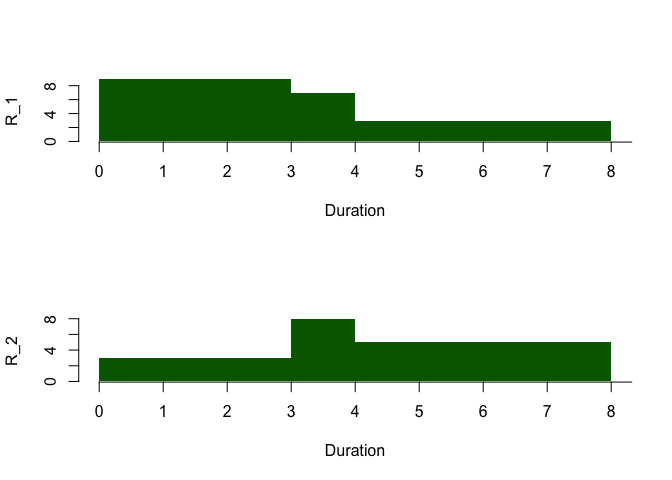

```
#>     R_1 R_2
#> TPR   9   8
```

```r
## Plot resources for SST

tpr(TPT$SST,LD,TD,RD,res.graph = TRUE)
```

The function *tpr* calculates maximal resource demands and can specify a resource graph.

## Calculate minimal resource demands while keeping project duration

Minimizing resource allocation is a combinatorial (NP-hard) problem; therefore the meta-heuristic method is used to minimize the maximum resource demands. In this case, a non dominated sorting genetic algorithm II (NSGA-II) method is to minimize the maximum resource demands. In the case of multiple resources, a Pareto-optimal solution is found.

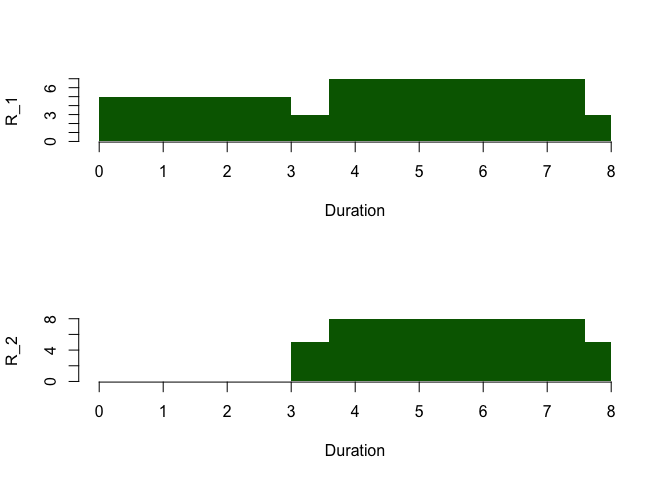

```r
# Calculate (Pareto) optimal SST
RES<-paretores(LD,TD,RD)

# Plot resource graph
tpr(RES$SST,LD,TD,RD,res.graph = TRUE)
```

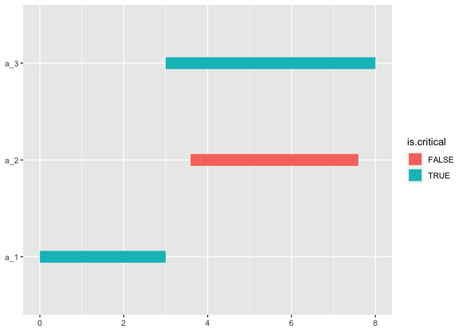

```r
# Plot Gantt Chart
plot(tpt(LD,TD,RES$SST),sched = "S")
```

## Specify a PDM matrix

The set of domains, namely the set of LD, TD, and CD, and as well as optionally QD, and RD specifies the project domain matrix (PDM).

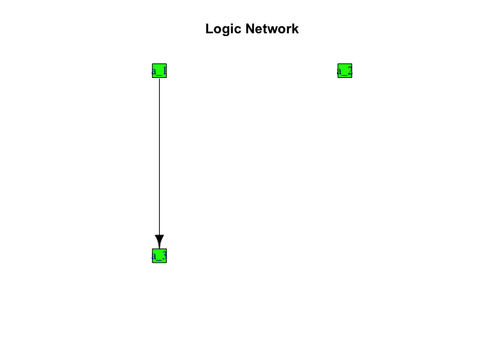

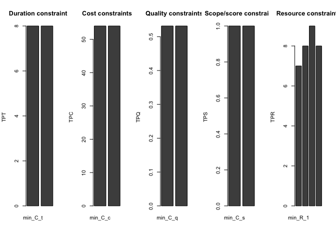

```r
PDM<-cbind(LD,TD,CD,q,RD)
class(PDM)<-"PDM_matrix"

summary(PDM,w=1,Rs=2)
plot(PDM,w=1,Rs=2)
```

# Generate a flexible project network to support HPMa

HPMa combines the features of TPMa (multiple completion modes), APMa (flexible project structure), and as well as XPMa (new, unplanned tasks).

```r
# Generation of PDM matrix for flexible project planning MFPP package.

# Define number of modes, flexibility factor and connectivity factor of a project scenerio.
N=5;ff=0.30;cf=0

# Define maximum value of time domain, Cost domain and Resourcces domain of a project scenerio.
mTD=3;mCD=4;mRD=3

# Define number of modes, number of resources,
# number of possible extra tasks (nW), scale and quality domain of a project scenerio.

w=2;nR=2;nW=1
scale=1.6

PDM<-generatepdm(N,ff,cf,mTD,mCD,mRD,w,nR,nW,scale,QD=TRUE,lst=TRUE)

summary(PDM) # Summary of PDM list
```

```
#>
#> summary PDM list:
#>
#> Number of completion modes (w):  2
#> Number of resources (Rs):  2
#> summary PDM matrix:
#>           a_1       a_2       a_3 a_4 a_5 a_6      t_1      t_2      c_1
#> a_1 0.8996805 1.0000000 0.0000000   1   1   0 2.809700 2.844662 2.214662
#> a_2 0.0000000 0.6023889 1.0000000   0   0   0 2.229386 2.752626 2.373684
#> a_3 0.0000000 0.0000000 0.9282092   0   0   0 2.195172 2.218452 3.394187
#> a_4 0.0000000 0.0000000 0.0000000   1   0   0 2.501854 2.647490 1.944377
#> a_5 0.0000000 0.0000000 0.0000000   0   1   0 1.393354 1.673179 3.257293
#> a_6 0.0000000 0.0000000 0.0000000   0   0   0 0.000000 0.000000 0.000000
#>          c_2       q_1       q_2    r_1.1    r_2.1     r_1.2    r_2.2
#> a_1 2.575008 0.5249795 0.5500175 1.646750 1.962195 0.7169741 0.772407
#> a_2 2.692506 0.9053482 0.9614625 2.672756 2.982463 2.0825999 2.207661
#> a_3 3.863461 0.7908406 0.8449759 2.765840 2.963731 2.3847546 2.613498
#> a_4 2.390865 0.5620840 0.6546224 1.915394 2.377417 1.8365222 2.025842
#> a_5 3.874045 0.4669808 0.5403975 1.938388 2.098193 2.5202051 2.828393
#> a_6 0.000000 0.0000000 0.0000000 0.000000 0.000000 0.0000000 0.000000
#> attr(,"class")
#> [1] "PDM_matrix"
#>
#> Minimal constraints:
#>
#> Summary of the PDM constraints structure:
#>
#> Time constraint (Ct):  2.501854
#> Const constraint (Cc):  5.20167
#> Score/scope constraint (Cs):  0.3768358
#> Quailty constraint (Cq):  0.1257496
#>
#> Maximal constraints:
#>
#> Summary of the PDM constraints structure:
#>
#> Time constraint (Ct):  4.971078
#> Const constraint (Cc):  15.39588
#> Score/scope constraint (Cs):  0.8918022
#> Quailty constraint (Cq):  0.5998342
#> Resource constraint(s) (CR):
#>          R_1      R_2
#> TPR 7.458073 7.467733
```

PDM_matrix contains only the PDM matrix, while PDM_list also contains, the number of completion modes (w), and as well as number of resources (Rs).

## Plot main structures of flexible project structures

**Minimal structure:** Contains only mandatory tasks and fixed dependencies. It provides the lowest quality / cost / time demands when the least quality / cost / shortest completion modes are specified for each task.

**Maximal structure:** Contains both mandatory and supplementary tasks and as well as both fixed and flexible dependencies. It provides the highest quality / greatest cost / time demands when the highest quality / greatest cost / longest completion modes are specified for each task.

**Minimax structure:** Contains only mandatory tasks, but both fixed and flexible dependencies. It can provide the lowest resource demands.

**Maximin structure:** Contains both mandatory and supplementary tasks, but only fixed dependencies. It can provide the greatest resource demands.

**Most-likely structure:** The round value of LD provides the most-likely structure.

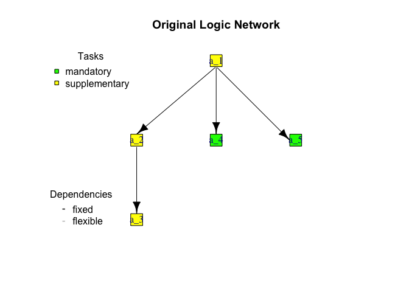

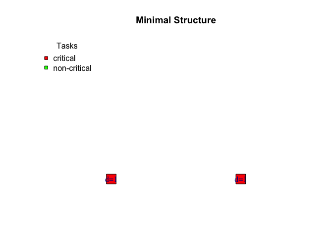

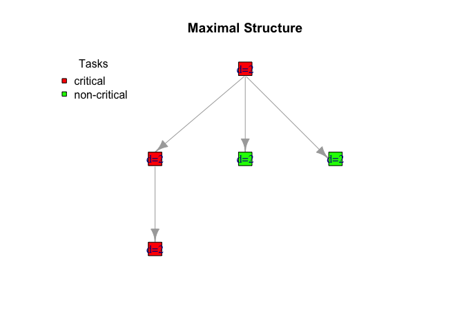

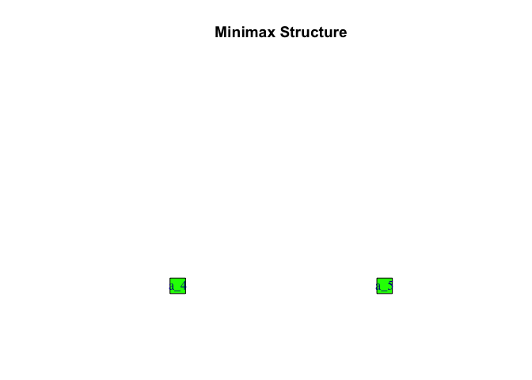

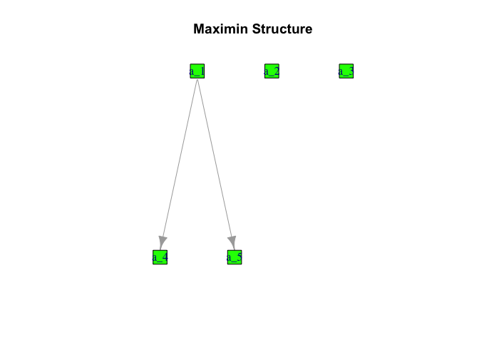

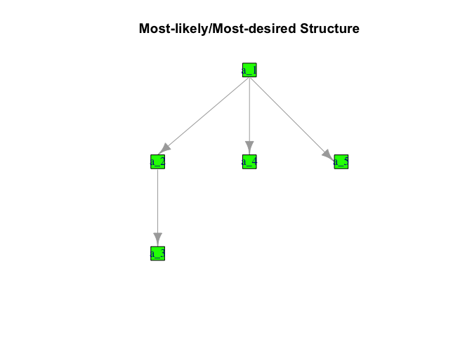

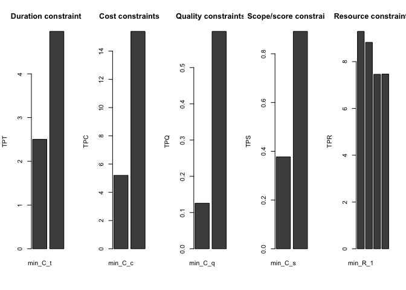

```r
plot(PDM) # Plot PDM structures
```

## Get most likely/most desired structure

If it is assumed, that depending on the context, the score values indicate the relative importance/probability of inclusion is the one minus the score values of exclusion, such occurrence/dependency has to be kept, where the score value is not less than 0.5.

```r
# Get most likely / most desired project structure list (PSM_list)
PSM_list<-get.structures(PDM,type = "most")$moststruct
summary(PSM_list)
```

```
#>
#> summary PDM list:
#>
#> Number of completion modes (w):  2
#> Number of resources (Rs):  2
#> summary PDM matrix:
#>     a_1 a_2 a_3 a_4 a_5 a_6      t_1      t_2      c_1      c_2       q_1
#> a_1   1   1   0   1   1   0 2.809700 2.844662 2.214662 2.575008 0.5249795
#> a_2   0   1   1   0   0   0 2.229386 2.752626 2.373684 2.692506 0.9053482
#> a_3   0   0   1   0   0   0 2.195172 2.218452 3.394187 3.863461 0.7908406
#> a_4   0   0   0   1   0   0 2.501854 2.647490 1.944377 2.390865 0.5620840
#> a_5   0   0   0   0   1   0 1.393354 1.673179 3.257293 3.874045 0.4669808
#> a_6   0   0   0   0   0   0 0.000000 0.000000 0.000000 0.000000 0.0000000
#>           q_2    r_1.1    r_2.1     r_1.2    r_2.2
#> a_1 0.5500175 1.646750 1.962195 0.7169741 0.772407
#> a_2 0.9614625 2.672756 2.982463 2.0825999 2.207661
#> a_3 0.8449759 2.765840 2.963731 2.3847546 2.613498
#> a_4 0.6546224 1.915394 2.377417 1.8365222 2.025842
#> a_5 0.5403975 1.938388 2.098193 2.5202051 2.828393
#> a_6 0.0000000 0.000000 0.000000 0.0000000 0.000000
#> attr(,"class")
#> [1] "PDM_matrix"
#>
#> Minimal constraints:
#>
#> Summary of the PDM constraints structure:
#>
#> Time constraint (Ct):  4.424558
#> Const constraint (Cc):  13.1842
#> Score/scope constraint (Cs):  1
#> Quailty constraint (Cq):  0.629259
#>
#> Maximal constraints:
#>
#> Summary of the PDM constraints structure:
#>
#> Time constraint (Ct):  4.971078
#> Const constraint (Cc):  15.39588
#> Score/scope constraint (Cs):  1
#> Quailty constraint (Cq):  0.691467
#> Resource constraint(s) (CR):
#>          R_1      R_2
#> TPR 7.458073 7.467733
```

## Calculate optimal schedules of completion modes

Optimal resource allocation can be calculated if completion modes are selected for each task.

```r
# Get PSM matrix
# Drop excluded tasks, and their demands
PSM<-round(truncpdm(PSM_list$PDM))

w<-PSM_list$w # Get number of completion modes
Rs<-PSM_list$Rs # Get number of resurces

DSM<-PSM[,1:nrow(PSM)] # Get PSM matrix

# Get time demands (time domain, TD)
TD<-PSM[,paste("t",1:w,sep = "_")]

# Get resource demands (resource domain, RD)
RD<-PSM[,tail(colnames(PSM),w*Rs)]

# Calculate optimal schedules for both completion modes

RES1<-paretores(DSM,TD[,1],RD[,1:Rs])
RES2<-paretores(DSM,TD[,2],RD[,(Rs+1):(2*Rs)])
```

## Plot optimal schedules and resource graph of completion modes

### Schedule of completion mode 1

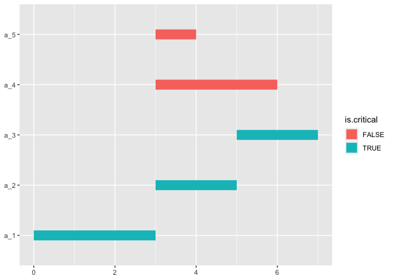

```r
plot(tpt(DSM,TD[,1],RES1$SST))
```

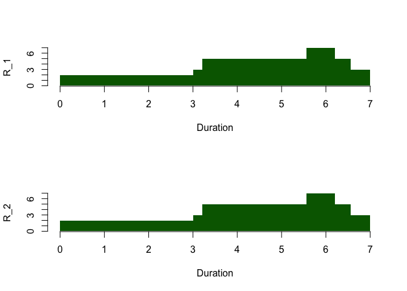

|  | R_1 | R_2 |
| --- | --- | --- |
| TPR | 7 | 7 |

```r
kable(tpr(RES1$SST,DSM,TD[,1],RD[,1:Rs],res.graph=TRUE))
```

### Schedule of completion mode 2

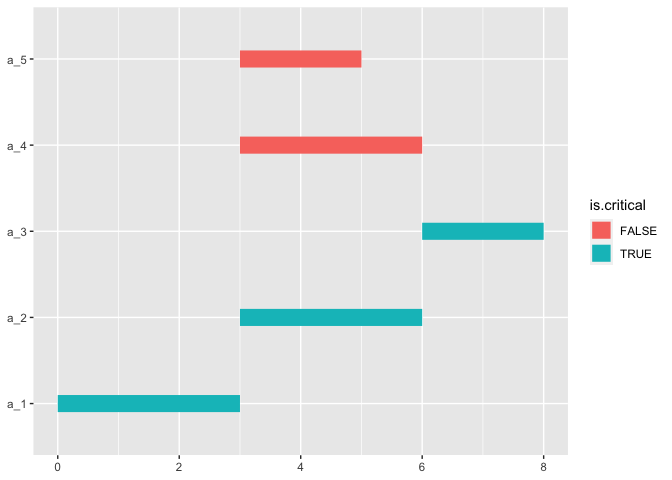

```r
plot(tpt(DSM,TD[,2],RES1$SST))
```

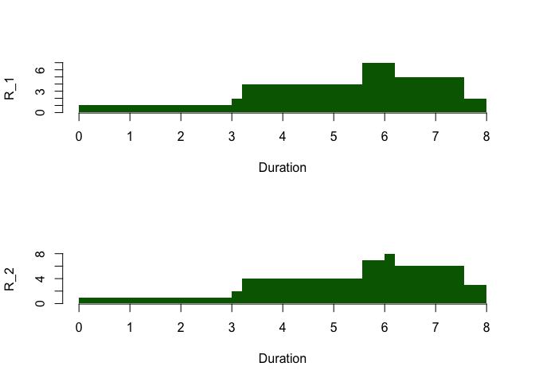

|  | R_1 | R_2 |
| --- | --- | --- |
| TPR | 7 | 8 |

```r
kable(tpr(RES1$SST,DSM,TD[,2],RD[,(Rs+1):(2*Rs)],res.graph=TRUE))
```

# Get a collection of projects

Two project database is included. The first one is Boctor’s (1993) databese, which contain 240 simulated projects. All of them contains 4 completion modes. It can be used to test algorithms for multi-mode resource-constrained project scheduling problem (MM-RC-PSP).

The second database is provided by Batselier & Vanhoucke (2015), which contains. 125 real projects. These projects contains only one completion mode, but it contains cost demands of tasks.

This example uses Boctor’s database.

```r
# Get the Boctor's simulation database

# Boctor, F. F. (1993).
# Heuristics for scheduling projects with resource restrictions and several resource-duration modes.
# The International Journal of Production Research,
# 31(11), 2547–2558,
# https://doi.org/10.1080/00207549308956882.

data(Boctor)
Collection<-Boctor

summary(Collection)
```

```
#>
#>
#>
#> Summary of PDM collection:
#>
#> Number of projects:  240
#> List of projects:
#>  Project name:  boct1, w:  4, Rs:  1
#>  Project name:  boct10, w:  4, Rs:  2
#>  Project name:  boct100, w:  4, Rs:  2
#>  Project name:  boct101, w:  4, Rs:  4
#>  Project name:  boct102, w:  4, Rs:  4
#>  Project name:  boct103, w:  4, Rs:  1
#>  Project name:  boct104, w:  4, Rs:  1
#>  Project name:  boct105, w:  4, Rs:  2
#>  Project name:  boct106, w:  4, Rs:  2
#>  Project name:  boct107, w:  4, Rs:  4
#>  Project name:  boct108, w:  4, Rs:  4
#>  Project name:  boct109, w:  4, Rs:  1
#>  Project name:  boct11, w:  4, Rs:  4
#>  Project name:  boct110, w:  4, Rs:  1
#>  Project name:  boct111, w:  4, Rs:  2
#>  Project name:  boct112, w:  4, Rs:  2
#>  Project name:  boct113, w:  4, Rs:  4
#>  Project name:  boct114, w:  4, Rs:  4
#>  Project name:  boct115, w:  4, Rs:  1
#>  Project name:  boct116, w:  4, Rs:  1
#>  Project name:  boct117, w:  4, Rs:  2
#>  Project name:  boct118, w:  4, Rs:  2
#>  Project name:  boct119, w:  4, Rs:  4
#>  Project name:  boct12, w:  4, Rs:  4
#>  Project name:  boct120, w:  4, Rs:  4
#>  Project name:  boct121, w:  4, Rs:  1
#>  Project name:  boct122, w:  4, Rs:  1
#>  Project name:  boct123, w:  4, Rs:  2
#>  Project name:  boct124, w:  4, Rs:  2
#>  Project name:  boct125, w:  4, Rs:  4
#>  Project name:  boct126, w:  4, Rs:  4
#>  Project name:  boct127, w:  4, Rs:  1
#>  Project name:  boct128, w:  4, Rs:  1
```

[output cut: 192 more lines]

```
#>  Project name:  boct86, w:  4, Rs:  1
#>  Project name:  boct87, w:  4, Rs:  2
#>  Project name:  boct88, w:  4, Rs:  2
#>  Project name:  boct89, w:  4, Rs:  4
#>  Project name:  boct9, w:  4, Rs:  2
#>  Project name:  boct90, w:  4, Rs:  4
#>  Project name:  boct91, w:  4, Rs:  1
#>  Project name:  boct92, w:  4, Rs:  1
#>  Project name:  boct93, w:  4, Rs:  2
#>  Project name:  boct94, w:  4, Rs:  2
#>  Project name:  boct95, w:  4, Rs:  4
#>  Project name:  boct96, w:  4, Rs:  4
#>  Project name:  boct97, w:  4, Rs:  1
#>  Project name:  boct98, w:  4, Rs:  1
#>  Project name:  boct99, w:  4, Rs:  2
```

## Get a project structure from the collection

```r
I<-2 # I-th number of project

PDM_list<-Collection[[I]]$PDM_list
PDM<-PDM_list$PDM
w<-PDM_list$w
Rs<-PDM_list$Rs

summary(PDM_list)
```

```
#>
#> summary PDM list:
#>
#> Number of completion modes (w):  4
#> Number of resources (Rs):  2
#> summary PDM matrix:
#>      a_1 a_2 a_3 a_4 a_5 a_6 a_7 a_8 a_9 a_10 a_11 a_12 a_13 a_14 a_15 a_16
#> a_1    1   0   1   0   0   0   0   0   0    0    0    0    0    0    0    0
#> a_2    0   1   0   0   0   0   1   0   0    0    0    0    0    0    0    0
#> a_3    0   0   1   1   1   1   0   0   0    0    0    0    0    0    0    0
#> a_4    0   0   0   1   0   0   1   0   1    0    0    0    0    0    0    0
#> a_5    0   0   0   0   1   0   0   1   0    0    0    0    0    0    0    0
#> a_6    0   0   0   0   0   1   1   1   0    0    0    0    0    0    0    0
#> a_7    0   0   0   0   0   0   1   0   0    1    0    0    0    0    0    0
#> a_8    0   0   0   0   0   0   0   1   1    0    0    0    0    0    0    0
#> a_9    0   0   0   0   0   0   0   0   1    1    0    0    0    0    0    0
#> a_10   0   0   0   0   0   0   0   0   0    1    1    0    1    0    0    0
#> a_11   0   0   0   0   0   0   0   0   0    0    1    1    0    1    0    0
#> a_12   0   0   0   0   0   0   0   0   0    0    0    1    0    0    0    1
#> a_13   0   0   0   0   0   0   0   0   0    0    0    0    1    0    1    0
#> a_14   0   0   0   0   0   0   0   0   0    0    0    0    0    1    1    0
#> a_15   0   0   0   0   0   0   0   0   0    0    0    0    0    0    1    1
#> a_16   0   0   0   0   0   0   0   0   0    0    0    0    0    0    0    1
#> a_17   0   0   0   0   0   0   0   0   0    0    0    0    0    0    0    0
#> a_18   0   0   0   0   0   0   0   0   0    0    0    0    0    0    0    0
#> a_19   0   0   0   0   0   0   0   0   0    0    0    0    0    0    0    0
#> a_20   0   0   0   0   0   0   0   0   0    0    0    0    0    0    0    0
#> a_21   0   0   0   0   0   0   0   0   0    0    0    0    0    0    0    0
#> a_22   0   0   0   0   0   0   0   0   0    0    0    0    0    0    0    0
#> a_23   0   0   0   0   0   0   0   0   0    0    0    0    0    0    0    0
#> a_24   0   0   0   0   0   0   0   0   0    0    0    0    0    0    0    0
#> a_25   0   0   0   0   0   0   0   0   0    0    0    0    0    0    0    0
#> a_26   0   0   0   0   0   0   0   0   0    0    0    0    0    0    0    0
#> a_27   0   0   0   0   0   0   0   0   0    0    0    0    0    0    0    0
#> a_28   0   0   0   0   0   0   0   0   0    0    0    0    0    0    0    0
#> a_29   0   0   0   0   0   0   0   0   0    0    0    0    0    0    0    0
#> a_30   0   0   0   0   0   0   0   0   0    0    0    0    0    0    0    0
#> a_31   0   0   0   0   0   0   0   0   0    0    0    0    0    0    0    0
#> a_32   0   0   0   0   0   0   0   0   0    0    0    0    0    0    0    0
#> a_33   0   0   0   0   0   0   0   0   0    0    0    0    0    0    0    0
```

[output cut: 227 more lines]

```
#>
#> Time constraint (Ct):  80
#> Const constraint (Cc):  0
#> Score/scope constraint (Cs):  1
#>
#> Maximal constraints:
#>
#> Summary of the PDM constraints structure:
#>
#> Time constraint (Ct):  391
#> Const constraint (Cc):  0
#> Score/scope constraint (Cs):  1
#> Resource constraint(s) (CR):
#>     R_1 R_2
#> TPR  15  11
```

### Plot the structure of the selected project

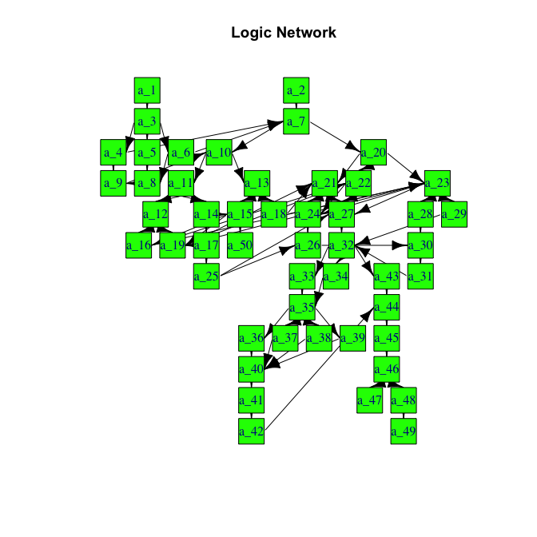

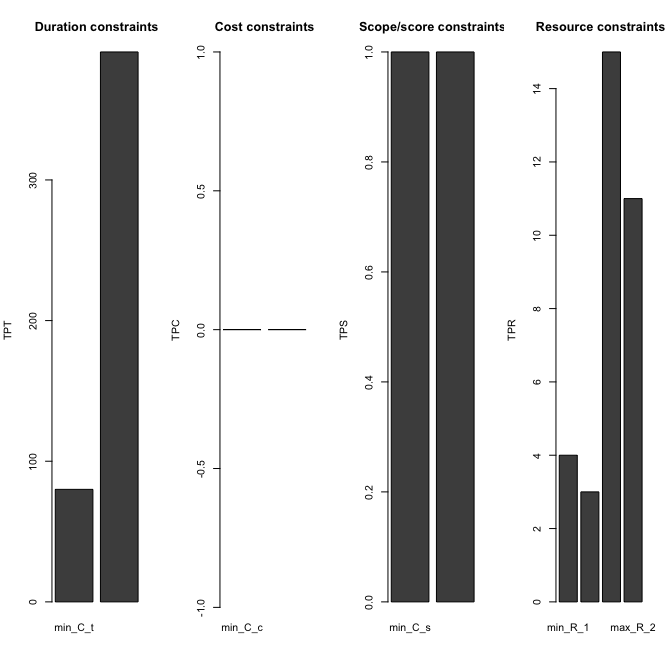

```r
plot(PDM_list)
```

### Plot Gantt Charts by completion modes

```r
PSM<-PDM_list$PDM
DSM<-PSM[,1:nrow(PSM)] # Get PSM matrix

# Get time demands (time domain, TD)
TD<-PSM[,paste("t",1:w,sep = "_")]

# Plot 1st completion mode, scheduled by EST
plot(tpt(DSM,TD[,1]))
```

[output not shown]

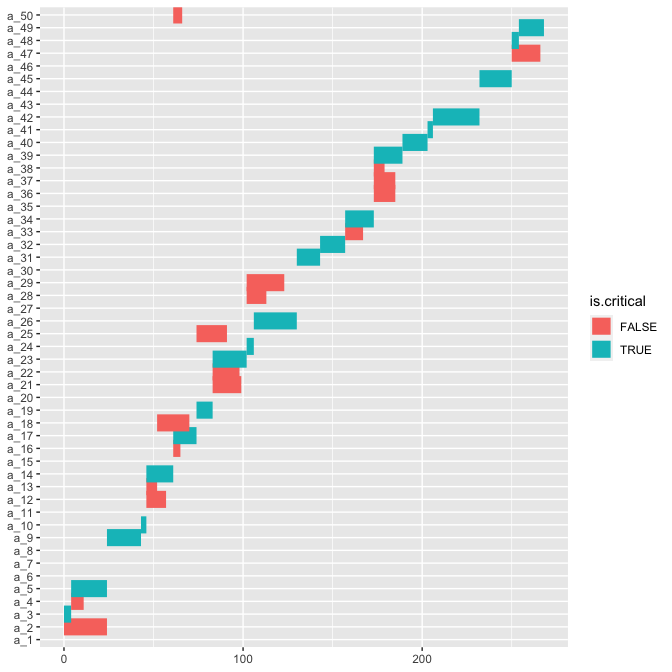

```r
# Plot 2nd completion mode, scheduled by EST
plot(tpt(DSM,TD[,2]))
```

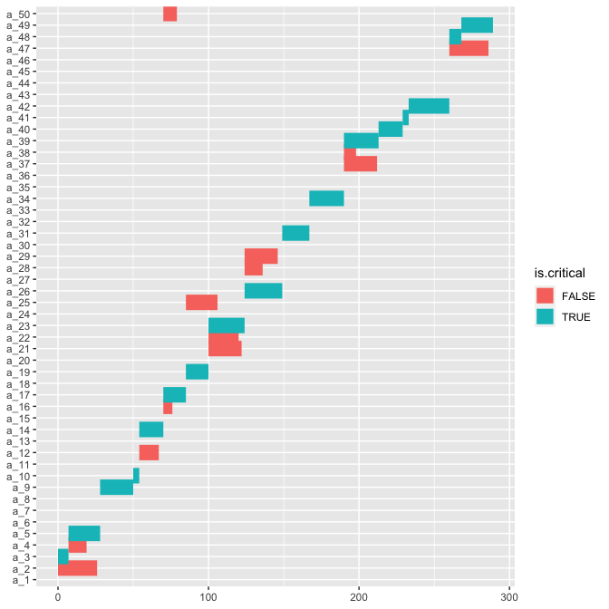

```r
# Plot 3rd completion mode, scheduled by EST
plot(tpt(DSM,TD[,3]))
```

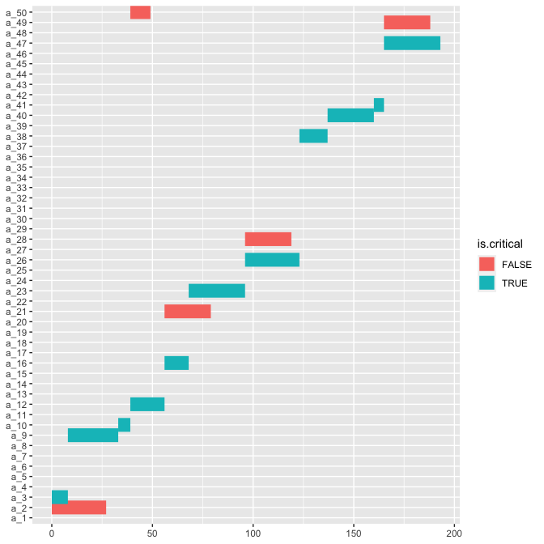

```r
# Plot 4th completion mode, scheduled by EST
plot(tpt(DSM,TD[,4]))
```

In the case of project risk analysis, one of the most frequently used method is the sensitivity analysis. The sensitivity analysis in mfpp contains three phases.

Phase 1: Effects of uncertainty Phase 2: Effects of shocks Phase 3: Structural changing

These phases can be done in a sequential, or in a separate way.

Phases follow the logic of Kosztyan et. al. (2020).

# Sensitivity analysis

Table 2 shows that phase 1 and phase 2 vary demands, while phase 3 varies the project structure. The effect of phase 1 performs on the entire project, while phase 2 and phase 3 select demands or structural elements.

|  | Changes |  |  |
| --- | --- | --- | --- |
| Phases | Demands | Structure | Selection |
| Phase 1 | X |  |  |
| Phase 2 | X |  | X |
| Phase 3 |  | X | X |

**Table 2:** Effects of phases in sensitivity analysis

## Effects of uncertainty

These phases can be performed in a sequential, or in a separate way.

The changed demands are generated by the interval between $[o+a,o+b]$, where $o$ is the original value. The random generator can follow uniform (=default), or beta distribution.

**These changes will be performed for all kinds of demands for each task.**

```r
# Changes of demands followed by uniform distribution (default)
PSM1<-phase1(PSM,a=-0.2,b=0.4)

# Changes of demands followed by beta distribution
PSM1b<-phase1(PSM,a=-0.2,b=0.4,pdftype="beta")

TD1<-PSM1[,paste("t",1:w,sep = "_")]
TD1b<-PSM1b[,paste("t",1:w,sep = "_")]

# Plot original 1st completion mode, scheduled by EST
plot(tpt(DSM,TD[,1]))
```

[output not shown]

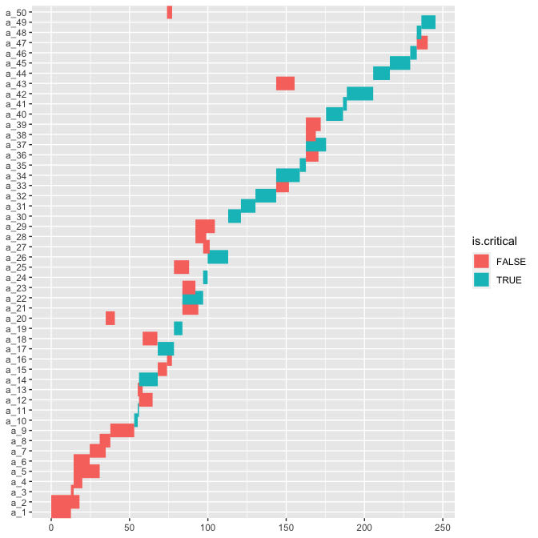

```r
# Plot changed 1st completion mode, scheduled by EST
plot(tpt(DSM,TD1[,1]))
```

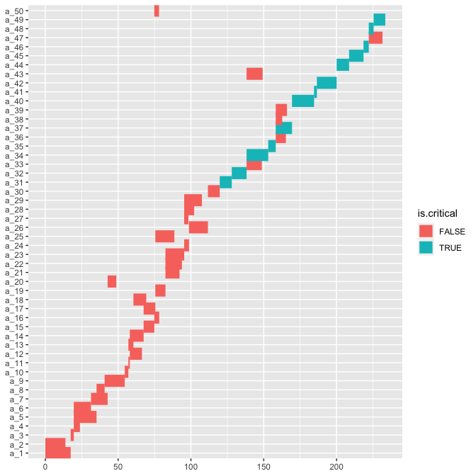

```r
# Plot changed 1st completion mode, scheduled by EST
plot(tpt(DSM,TD1b[,1]))
```

Phase 1 can be used to analyze of uncertainty of the estimation.

## Effects of shocks

Phase 2 simulates the shock effects. Where $p$ percent of task demands can be increased up to $s$ times.

```r
# Changes of demands followed by uniform distribution (default)
# p: percentage of task selection
# s: maximal scale effect

PSM2<-phase2(PSM,p=0.2,s=10)

TD2<-PSM2[,paste("t",1:w,sep = "_")]

# Plot original 1st completion mode, scheduled by EST
plot(tpt(DSM,TD[,1]))
```

[output not shown]

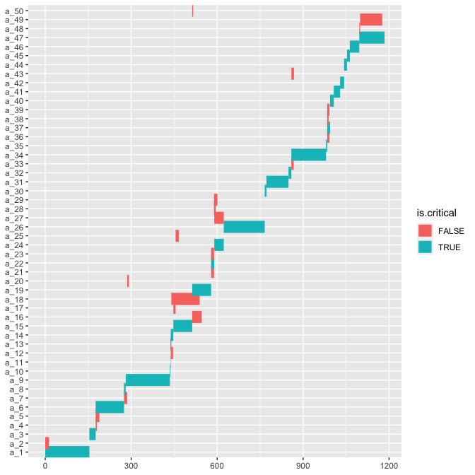

```r
# Plot changed 1st completion mode, scheduled by EST
plot(tpt(DSM,TD2[,1]))
```

Phase 2 is worth to simulate the shock effect, where not all task demands are changed, but the changes are significant.

## Structural changes

Phase 3 selects $P$ percent of nodes (i.e. tasks) or arcs (i.e. dependencies), where the score value can be changed up to the maximal change effect $S$.

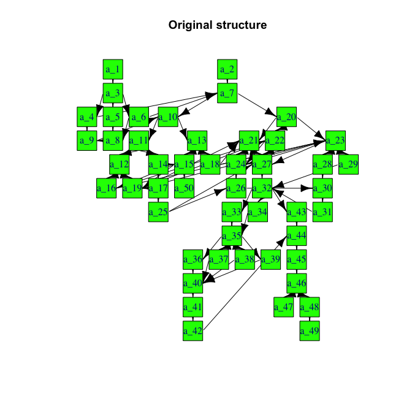

```r
# Changes of demands followed by uniform distribution (default)
# P: percentage of selection
# S: maximal change effect

PDMp<-phase3(PSM,0.1,0.5) # New possible dependencies
PDMn<-phase3(PSM,0.1,-0.5) # Completion and dependencies will be flexible

# Plot original structure
plot(PSM,type = "orig",main="Original structure")
```

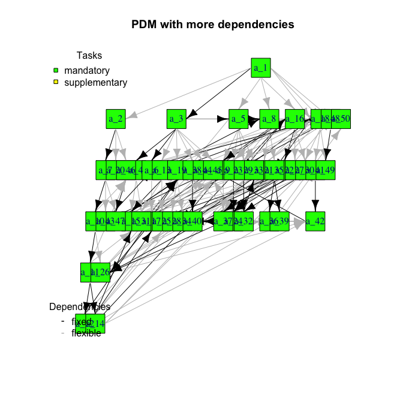

```r
# Plot PDM with more restrictions
plot(PDMp,type = "orig",main="PDM with more dependencies")
```

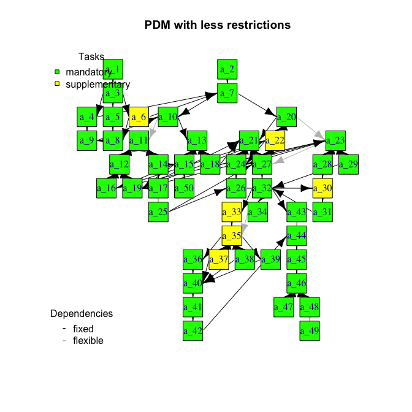

```r
# Plot PDM with less restrictions
plot(PDMn,type = "orig",main="PDM with less restrictions")
```

Phase 3 is worth simulating the changes in customers’ priorities and the technological changes. In the case of S<0 the plan will be more flexible, while S>0 increases priorities and can produce new dependencies.

# References

Batselier, J. & Vanhoucke, M. (2015). Construction and evaluation framework for a real-life project database. International Journal of Project Management, 33(3), 697–710, https://doi.org/10.1016/j.ijproman.

Boctor, F. F. (1993). Heuristics for scheduling projects with resource restrictions and several resource-duration modes. The international journal of production research, 31(11), 2547–2558, https://doi.org/10.1080/00207549308956882.

Kosztyan, Z.T., Jakab, R., Novak, G. and Hegedus, C., 2020. Survive IT! Survival analysis of IT project planning approaches. Operations Research Perspectives, 7, p.100170, https://doi.org/10.1016/j.orp.2020.100170

Kosztyan, Z.T. and Szalkai, I., 2020. Multimode resource-constrained project scheduling in flexible projects. Journal of Global Optimization, 76(1), pp. 211-241, https://doi.org/10.1007/s10898-019-00832-8

Kosztyan, Z.T., 2022. MFPP: Matrix-based flexible project planning. SoftwareX, 17, p.100973, https://doi.org/10.1016/j.softx.2022.100973